# PA1_template

yuchao

June 11, 2016

This is the R markdown file for the first project in Reproduciable Research Course.

Dataset is downloaded and saved locally, before read the data, first set the working directory to the corresponding folder containing the data file.

## Step 1. Loading and preprocessing the data

```r
setwd("C:/A_nnealing/2016Spring/Data_Science_Serial/DS-Course5/project/repdata")
mydt <- read.csv("activity.csv", stringsAsFactors = FALSE)
str(mydt)
```

```
## 'data.frame':    17568 obs. of  3 variables:
##  $ steps   : int  NA NA NA NA NA NA NA NA NA NA ...
##  $ date    : chr  "2012-10-01" "2012-10-01" "2012-10-01" "2012-10-01" ...
##  $ interval: int  0 5 10 15 20 25 30 35 40 45 ...
```

## Step 2. Calculate the total and mean number of steps per day without NA value

```r
total <- aggregate(mydt$steps, by=list(date=factor(mydt$date)), FUN=sum, na.rm = TRUE)
head(total)
```

```
##         date     x
## 1 2012-10-01     0
## 2 2012-10-02   126
## 3 2012-10-03 11352
## 4 2012-10-04 12116
## 5 2012-10-05 13294
## 6 2012-10-06 15420
```

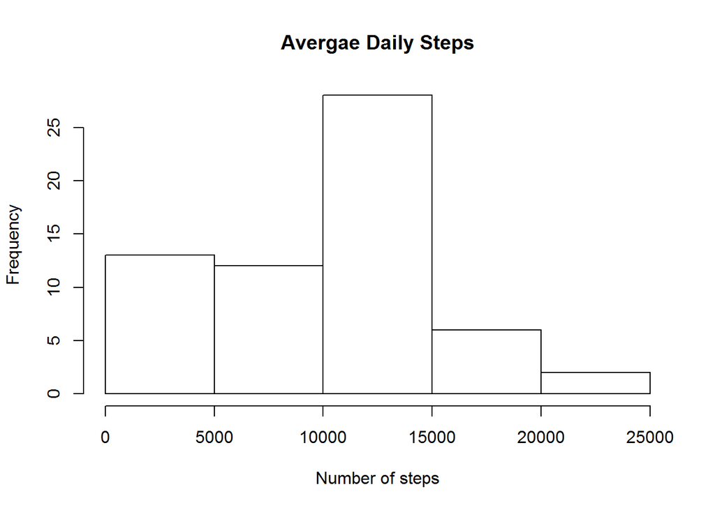

```r
hist(total$x,xlab = "Number of steps", main = "Avergae Daily Steps")
```

```r
meanS <- mean(total$x)
medS <- median(total$x)
```

The mean and median of the total number of steps taken per day is 9354.2295082 and 10395 respectively.

## Step 3. Estimate average daily activity pattern

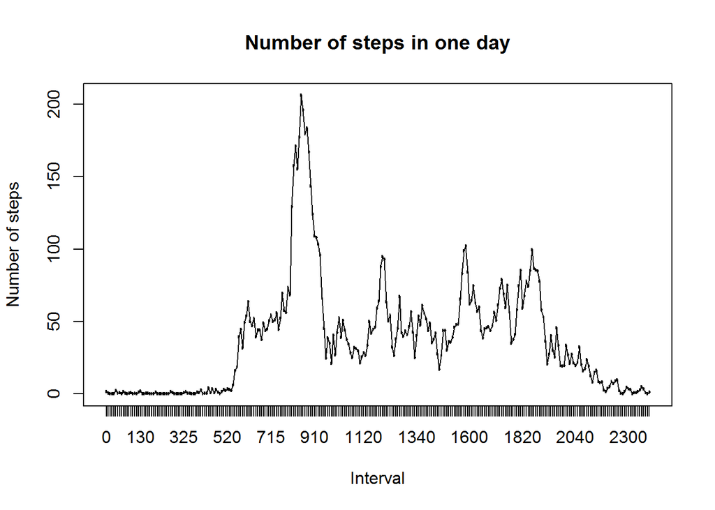

```r
daily <- aggregate(mydt$steps, by=list(factor(mydt$interval)),FUN=mean,na.rm = TRUE)
plot(daily$Group.1,daily$x, xlab = "Interval", ylab = "Number of steps", main = "Number of steps in one day")
points(daily$Group.1,daily$x,type = "l")
```

```r
max_day <- daily$Group.1[daily$x == max(daily$x)]
```

On average across all the days, the 5-minite interval of 835 contains the maximum number of steps.

## Step 4. Imputing missing values

To impute the missing values, the record of steps with NA will be filled using the average step numbers in the same 5-minute interval.

```r
steps <- vector(,dim(mydt)[1])
for(i in 1:dim(mydt)[1]){
  if(is.na(mydt$steps[i])){
    avg <- daily$x[daily$Group.1 == mydt$interval[i]]
    steps[i] <- avg
  }
  else{
    steps[i] <- mydt$steps[i]
  }
}
new_dt <- data.frame(steps,date = mydt$date,time = mydt$interval)
```

## Step 5. Estimate the total number of steps per day using new dataset with imputed step values

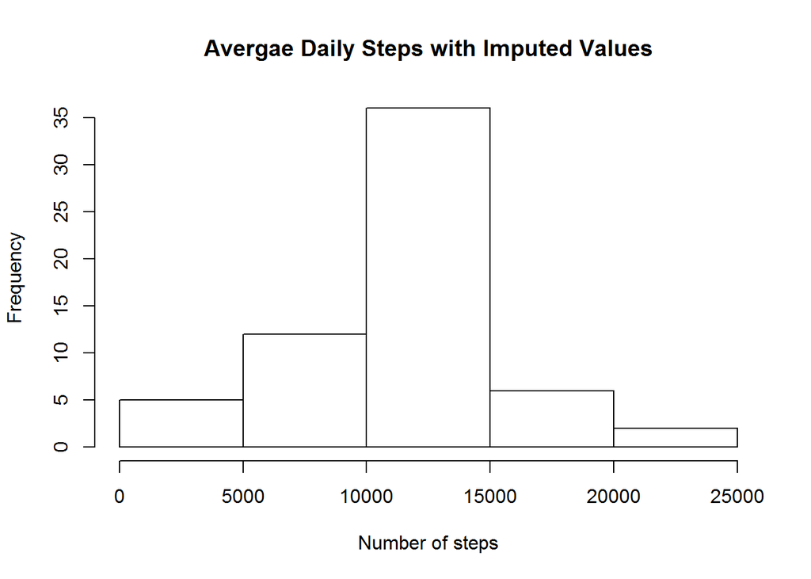

```r
new_total <- aggregate(new_dt$steps, by=list(date=factor(new_dt$date)), FUN=sum)
hist(new_total$x, xlab = "Number of steps", main = "Avergae Daily Steps with Imputed Values")
```

```r
new_meanS <- mean(new_total$x)
new_medS <- median(new_total$x)
```

Comparing with the results from the original dataset, imputing the NA value with the average steps in the same interval increases the total number of steps per day.

## Step 6. Differences in activity patterns between weekdays and weekends

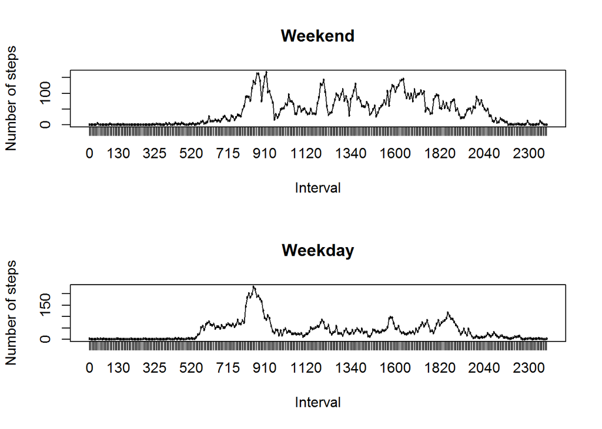

```r
weekday <- weekdays(as.Date(new_dt$date))
for(i in 1:length(weekday)){
  if(weekday[i] != "Saturday" && weekday[i] != "Sunday"){
    weekday[i] <- "weekday"
  }
  else{
    weekday[i] <- "weekend"
  }
}
new_dt["weekday"] <- as.factor(weekday)
f <- split(new_dt,new_dt$weekday)
day <- as.data.frame(f[1])[,c(1,3)]
end <- as.data.frame(f[2])[,c(1,3)]
day_step <- aggregate(day$weekday.steps, by=list(time = factor(day$weekday.time)),FUN=mean)
end_step <- aggregate(end$weekend.steps, by=list(time = factor(end$weekend.time)),FUN=mean)

par(mfrow = c(2,1))
plot(end_step$time,end_step$x,main = "Weekend",xlab = "Interval", ylab = "Number of steps")
points(end_step$time,end_step$x,type = "l")
plot(day_step$time,day_step$x,main = "Weekday",xlab = "Interval", ylab = "Number of steps")
points(day_step$time,day_step$x,type = "l")
```